Sentinel-1 InSAR · Flores, Indonesia · M7.7, 14 August 2026

# The Flores Shortfall

The ground moved about a tenth of what the finite-fault model said it would. Four interferogram pairs, three processing chains, and one number that refuses to grow.

USGS model  
predicts

54 cm

Sentinel-1  
measures

6.8 cm range 4.4–8.6

Line-of-sight displacement, 20–30 km from the epicentre, on the nearest coherent land. The epicentre itself lies 28 km offshore.

[interactive chart not shown]

Wrapped phase — one colour cycle= 2.8 cm of range change

[ 4.44 – 8.59 ]*cm, near field*

## Three processing chains, one dataset, one answer

The spread that remains is not scatter. It tracks how much long-wavelength signal each chain removed: a linear deramp takes out exactly the component a large earthquake produces, so the more deramping, the smaller the answer. The true value is bracketed, not uncertain.

| Ring | GMTSAR | MintPy | insardev | Noise sd |
| --- | --- | --- | --- | --- |
| 20–30 km | −7.53 | −6.50 | −8.59 | 1.65 |
| 30–40 km | −4.81 | −4.13 | −4.21 | 1.30 |
| 40–50 km | −0.99 | −0.94 | −0.60 | 1.05 |
| 50–65 km | +0.84 | +1.05 | +1.33 | 0.99 |

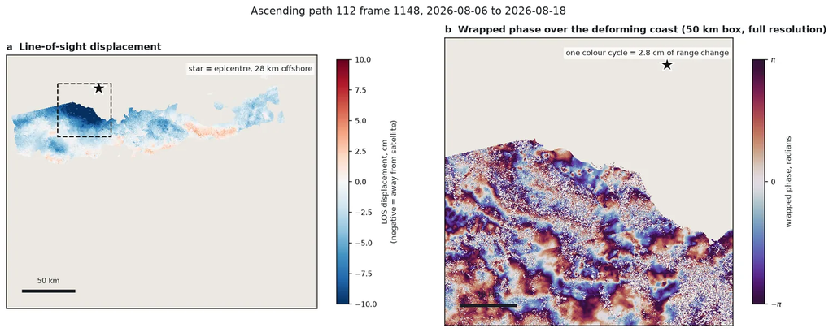

**The lobe sits where the source is.** Displacement decays east and away from the epicentre, which is what deformation does and what atmosphere does not. At full 40 m resolution the wrapped phase over that same coast resolves into ordered fringes rather than speckle — coherence there is median 0.41.

[ 3.3 – 4.4 ]*sigma, 0 of 76*

## Measured against 76 earthquake-free intervals

A 78-epoch time series on this exact frame yields 76 quiet 12-day intervals — an empirical record of what this scene's atmosphere and orbit errors do when nothing happens.

The co-seismic step is −7.43 cm raw and −4.44 cm after deramping, at 4.4 σ and 3.3 σ. **Not one of the 76 quiet intervals is as large as either.** The step is not compared against zero, or against a model, but against the same frame's own behaviour.

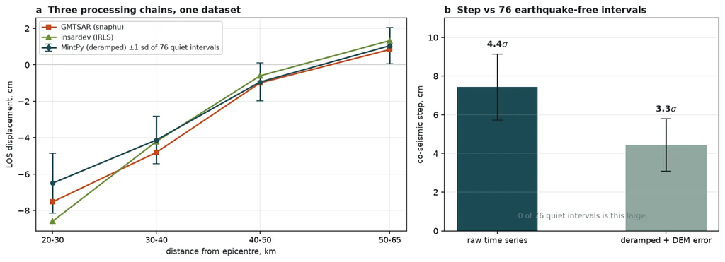

**Error bars are earned, not assumed.** Every bar is the spread of 76 real intervals on this frame, not a propagated formal uncertainty.

[ 0.4 ]*cm apart, two tracks*

## Agreement between chains proves the software. Only a second geometry proves the Earth.

All three chains eat the same two acquisitions, so the atmosphere of 18 August is common to every one of them. Their agreement rules out a processing artefact and says nothing whatever about a weather one.

Two descending tracks break that circularity because neither shares an acquisition date with the ascending pair. Their *raw* profiles disagree completely. Remove each track's own best-fit plane — the long-wavelength component that orbit error and atmosphere produce — and they land 0.4 cm apart in the near field. Different ramps; one residual underneath.

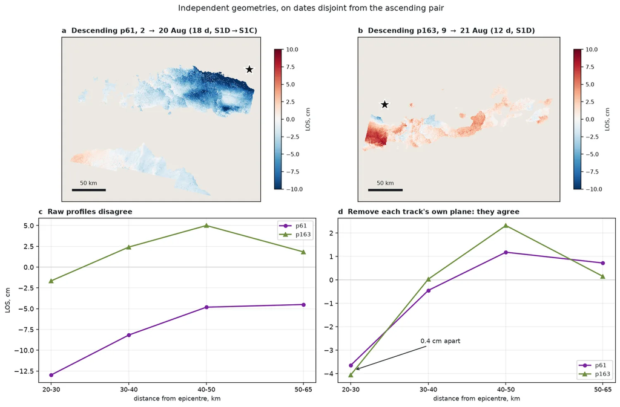

**What survives plane removal.** Source-centred structure of 4.83 cm on p61 against 0.57 cm in its quiet control, and 6.38 against 1.61 on p163. Both tracks are descending, differing in incidence angle rather than heading — there is still no third look direction.

[ null ]*coherence vs damage*

## The radar sees the ground move. It barely sees the damage.

Coherence change — the standard damage proxy — carries no spatial relationship to the rupture at all. Its maximum sits at 50–65 km, and the 130–200 km ring matches the near field.

The control that makes this readable: coherence cannot genuinely *improve* because of an earthquake, yet 6.8% of pixels gain more than 0.2 against 18.5% losing it. That gap is the noise floor beneath the loss. And two tracks observing the same ground agree on normalised coherence change at only r = 0.44–0.58, which bounds what any single-track damage map can claim.

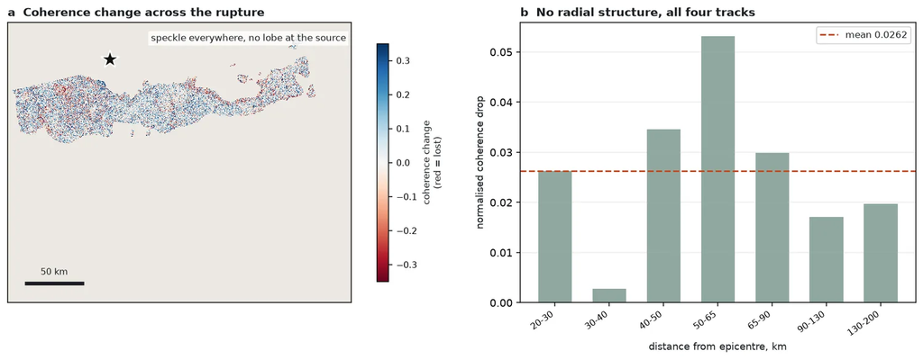

**Same ground, same frame, no lobe.** Compare the displacement map above, where the signal is unmistakable. Coherence change here is speckle at every distance out to 200 km.

### Claimed

Coherence loss separates badly from lightly damaged villages — and replicates across two geometries.

### Retracted

The two descending tracks share *zero* reports; they cover opposite ends of the island. The replication compared different villages.

### Partly restored

That retraction over-read the noise. The intervals overlap. A modest, real effect stands on the best-powered track — AUC 0.644 [0.539–0.744].

The fix was to stop treating unreported ground as undamaged ground. It is ground with no people, no signal, or no agency visit. A presence-only analysis with a *target-group background* — where every background point is somewhere a person did file something — holds accessibility fixed by construction. Controlling that bias **strengthened** the result rather than dissolving it.

[ 138 – 396 ]*of 452 reports*

## No single frame covers the island

Flores runs 340 km east to west; a Sentinel-1 frame is 250 km across. Because the along-track direction is nearly north–south, it is longitude that gets cut — and a frame's latitude range says nothing about it.

Frame 1148, the primary frame, holds 191 of 452 damage reports. The western third — Labuan Bajo and the Manggarai highlands, where the single largest cluster of 235 reports sits — falls outside it entirely. Complete coverage needs ascending *and* descending. Separately: Sentinel-1C has never once recorded the Flores frame on descending path 163, 0 of 8 passes since May, so the constellation's nominal six-day revisit does not apply to this ground.

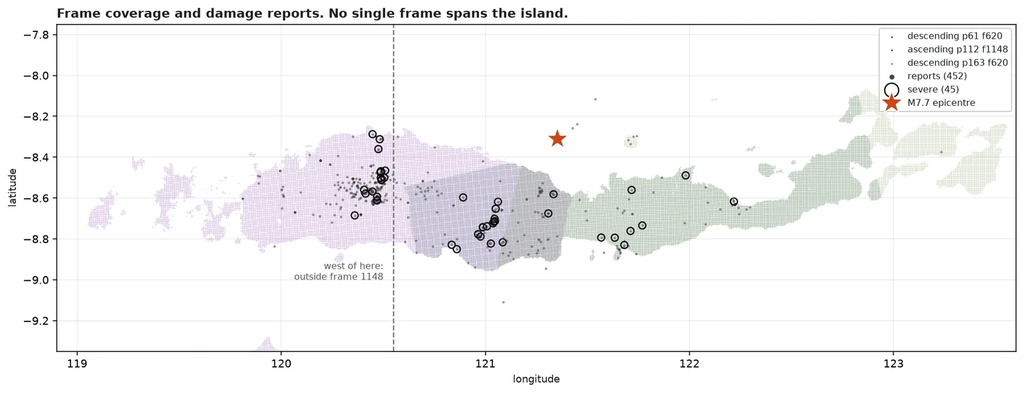

**Why the “replication” was an illusion.** The two descending tracks barely overlap, so they observe different villages and share no reports. That was geometry, not bad luck — and it should have been checked before treating three tracks as replicates.

[ 8 ]*errors caught*

## What went wrong, and what caught it

Every genuine advance here came from a control that could have failed. This is the ledger of the ones that did.

- Frame chosen for containing the epicentreThe epicentre is offshore. That frame held 4.9% of the deforming ground.land-coverage test
- A tidy cluster of the largest coherence dropsAll at 0 m elevation, 0° slope, 100 m from the sea. Shoreline, not damage.terrain check
- “Three chains agree” read as confirmationAll three share the same two acquisitions.naming the confound first
- Coherence–damage replication across geometriesThe two descending tracks share zero reports.common-report test
- That retraction, in turn too strongConfidence intervals overlap. Two noisy estimates are not a contradiction.presence-only re-analysis
- Submit guard keyed on job namesThe same granules under a new label would have re-bought 30 credits.granule-pair keying
- `include_los_displacement` recorded but ignoredHyP3 accepts the deprecated parameter and delivers no band.checking delivered files
- A damage map legend that read backwardsRdBu maps low values to red; the caption said blue for loss.reading the figure

Nine predictions were registered in writing while the final products were still queued. **Five held.** Two of the four failures moved the argument forward — the baseline-matched coherence drop came out at −0.008 rather than the predicted +0.012 to +0.022, confirming more firmly than expected that an earlier result had been a baseline artefact. One forced the retraction above.

## Still open

- ~30 Aug**A second post-event epoch.** Every track has only one. On a single track the co-seismic step and that day's atmosphere are not separable by any inversion — three tracks did not change that. Two post-event epochs difference against each other. This is worth more than any reprocessing of what exists.
- ~7 Sept**Precise orbits.** Would collapse the plane-versus-signal degeneracy that costs 2–3 cm on every profile.
- Pending**ERA5 tropospheric correction.** Unpublished for 18 August at the time of the run; the 6 August field is already cached.
- Fieldwork**Confirmed absences.** Turning a relative rate into a damage probability needs someone visiting places that filed no report and recording them as undamaged. No amount of radar substitutes for this.
- Fieldwork**Two landslide candidates.** −8.7046 / 121.5505 at 49 km and −8.7226 / 122.2152 at 106 km. Steep — 32° and 36° against a scene median of 17.5° — unreported, and visible in both baseline-matched tracks. Has anyone been to them?

**Reproducibility is not validity.** Three implementations of the same algorithms, run over the same two files, agreed to within a centimetre — and that agreement said nothing at all about the atmosphere they all shared. The result only became believable when a control was introduced that could have killed it: a quiet interval, a disjoint acquisition date, a background drawn from the same sampling process, or a terrain check on a finding that looked too good.